# Bladder Cancer Survival

Yi Lian

2025-01-02

# 1. Load data

# 2. Inclusion and exclusion

Begin with 14343 patients.

## 2.1 First line treatment start date bewteen 01/01/2011 and 09/30/2023

- Implicitly excludes untreated patients

Down to 9556 patients.

## 2.2 Remove patients who have received *clinical study drug*

Down to 8955 patients.

# 3. Endpoint definition

End of follow-up is the last interaction with a healthcare provider

- Event: death from `Enhanced_Mortality_V2.csv`.
- Censoring: the latest of
- The last visit date in `Visit.csv`
- The start date of the last oral drug in `Enhanced_AdvUrothelial_Orals.csv`
- The episode date of the last drug episode in `DrugEpisode.csv`.
- The `Line1StartDate`
- The `LastClinicNoteDate` in `Enhanced_AdvUrothelial_Progression.csv`.

# 4. Crude analysis

## 4.1 Define three cohorts based on Line 1 Start Date

- ICI first approval on 05/18/2016
- ADC first approval on 12/18/2019

## 4.2 Analysis

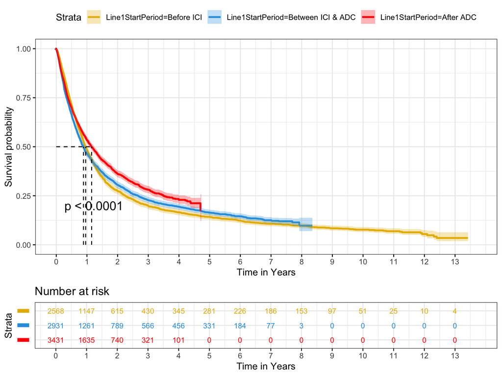

##### Crude median survival

```
## Call: survfit(formula = auc.surv ~ Line1StartPeriod, data = auc)
##
##                                       n events median 0.95LCL 0.95UCL
## Line1StartPeriod=Before ICI        2576   2154    350     330     370
## Line1StartPeriod=Between ICI & ADC 2943   2343    324     302     340
## Line1StartPeriod=After ADC         3436   2158    421     391     453
```

##### Crude 3-yr survival probability

```
## Call: survfit(formula = auc.surv ~ Line1StartPeriod, data = auc)
##
##                 Line1StartPeriod=Before ICI
##         time       n.risk      n.event     survival      std.err lower 95% CI
##     1.10e+03     4.31e+02     1.92e+03     1.99e-01     8.33e-03     1.84e-01
## upper 95% CI
##     2.16e-01
##
##                 Line1StartPeriod=Between ICI & ADC
##         time       n.risk      n.event     survival      std.err lower 95% CI
##     1.10e+03     5.66e+02     2.14e+03     2.28e-01     8.13e-03     2.12e-01
## upper 95% CI
##     2.44e-01
##
##                 Line1StartPeriod=After ADC
##         time       n.risk      n.event     survival      std.err lower 95% CI
##     1.10e+03     3.22e+02     2.11e+03     2.81e-01     9.45e-03     2.63e-01
## upper 95% CI
##     3.00e-01
```

##### Crude 2-yr survival probability

```
## Call: survfit(formula = auc.surv ~ Line1StartPeriod, data = auc)
##
##                 Line1StartPeriod=Before ICI
##         time       n.risk      n.event     survival      std.err lower 95% CI
##     7.30e+02     6.15e+02     1.75e+03     2.74e-01     9.20e-03     2.57e-01
## upper 95% CI
##     2.93e-01
##
##                 Line1StartPeriod=Between ICI & ADC
##         time       n.risk      n.event     survival      std.err lower 95% CI
##     7.30e+02     7.90e+02     1.94e+03     3.05e-01     8.83e-03     2.88e-01
## upper 95% CI
##     3.23e-01
##
##                 Line1StartPeriod=After ADC
##         time       n.risk      n.event     survival      std.err lower 95% CI
##     7.30e+02     7.40e+02     1.98e+03     3.62e-01     9.05e-03     3.45e-01
## upper 95% CI
##     3.81e-01
```

## 4.3 Descriptive analyses

Among first-line ICI initiators after 2016-05-18

- Median duration of ICI treatment
- Proportion of treatment for over 2 years
- Excluded 9 patients who died before the proposed start date of first-line ICI

```
##    Min. 1st Qu.  Median    Mean 3rd Qu.    Max.
##     0.0    50.0   131.0   311.2   387.0  2863.0
```

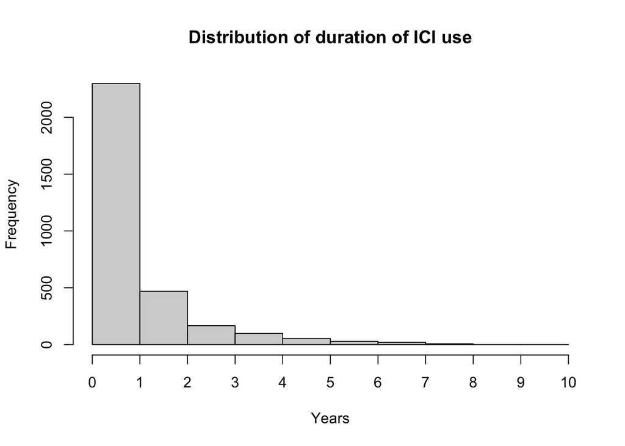

```
##
## FALSE  TRUE
##  2766   372
```

```
##
##  1-sample proportions test with continuity correction
##
## data:  table(!ici.start.end$ici.duration >= 365.25 * 2), null probability 0.5
## X-squared = 1824.9, df = 1, p-value < 2.2e-16
## alternative hypothesis: true p is not equal to 0.5
## 95 percent confidence interval:
##  0.1075479 0.1304917
## sample estimates:
##         p
## 0.1185468
```

- Median duration of ICI treatment is 131 days.
- Proportion of treatment for over 2 years is 0.119.

These could be underestimated because patients who are still alive and have an ICI end date close to their end of follow up are considered to discontinue ICI.

## 4.4 Table of number of ICI discontinuation and progression/death in each 2 months interval

##### Patients who are still receiving ICI treatment at the time of censoring are considered to have discontinued treatment.

```
##    Interval No.Start No.Disc No.Prog_Dead
## 1       0-2     3138     275          813
## 2       2-4     2050     107          608
## 3       4-6     1335      60          214
## 4       6-8     1061      52          109
## 5      8-10      900      40           86
## 6     10-12      774      45           58
## 7     12-14      671      50           49
## 8     14-16      572      47           35
## 9     16-18      490      34           34
## 10    18-20      422      24           21
## 11    20-22      377      31           12
## 12    22-24      334      26           15
## 13    24-26      293      17            9
## 14    26-28      267      16            8
## 15    28-30      243      21            2
## 16    30-32      220      10            6
## 17    32-34      204       9            3
## 18    34-36      192      13            1
```

## 4.5 Discontinuation patterns of ICI

- Proportion that discontinued treatment in the absence of associated progression or death by the next 3-month time point, among patients still on ICI treatment at 2 years.
- Interval 24-27 for the same analysis in 4.4

```
##    Interval No.Start No.Disc No.Prog_Dead
## 1       0-3     3138     268         1303
## 2       3-6     1567      84          422
## 3       6-9     1061      62          161
## 4      9-12      838      61          106
## 5     12-15      671      76           67
## 6     15-18      528      56           50
## 7     18-21      422      37           27
## 8     21-24      358      41           24
## 9     24-27      293      23           14
## 10    27-30      256      31            5
## 11    30-33      220      14            8
## 12    33-36      198      17            3
```

The proportion is 0.078.

# 5. Adjusted analysis

## 5.1 Covariates

##### Covariates measured at index date, which is the start date of first line treatment.

- E.g., the last record of `ecog` and `insurance` before `Line1StartDate`.

### Table 1

```
##                         Stratified by Line1StartPeriod
##                          level                     Before ICI
##   n                                                 2576
##   AgeAtLine1 (mean (SD))                           70.84 (9.65)
##   BirthSex (%)           F                           672 (26.1)
##                          M                          1903 (73.9)
##   Race (%)               Black or African American   131 ( 5.4)
##                          Other Race                  346 (14.4)
##                          White                      1932 (80.2)
##   StageAtDiagnosis (%)   Stage0                       14 ( 1.1)
##                          Stage1                       35 ( 2.8)
##                          Stage2                      113 ( 9.1)
##                          Stage3                      127 (10.2)
##                          Stage4                      954 (76.7)
##   EcogValueAtLine1 (%)   < 2                         992 (82.1)
##                          >= 2                        216 (17.9)
##   SmokingHistory (%)     FALSE                       713 (27.7)
##                          TRUE                       1863 (72.3)
##   Location (%)           Midwest                     288 (14.6)
##                          Northeast                   332 (16.9)
##                          South                      1006 (51.1)
##                          West                        342 (17.4)
##   Insurance (%)          Commercial                 1058 (54.3)
##                          Government                  718 (36.9)
##                          Other                       172 ( 8.8)
##   PracticeType (%)       ACADEMIC                    442 (17.2)
##                          COMMUNITY                  2134 (82.8)
##   PrimarySite (%)        Bladder                    2013 (78.1)
##                          Renal Pelvis                339 (13.2)
##                          Ureter                      190 ( 7.4)
##                          Urethra                      34 ( 1.3)
##                         Stratified by Line1StartPeriod
##                          Between ICI & ADC After ADC     SMD
##   n                       2943              3436
##   AgeAtLine1 (mean (SD)) 72.30 (9.42)      72.78 (9.36)   0.136
##   BirthSex (%)             763 (25.9)        965 (28.1)   0.032
##                           2179 (74.1)       2471 (71.9)
##   Race (%)                 146 ( 5.5)        160 ( 5.6)   0.047
##                            447 (16.8)        414 (14.4)
##                           2066 (77.7)       2296 (80.0)
##   StageAtDiagnosis (%)      14 ( 0.9)         15 ( 0.8)   0.322
##                             46 ( 2.9)         67 ( 3.5)
##                            234 (14.9)        345 (17.8)
##                            260 (16.5)        436 (22.5)
##                           1018 (64.8)       1073 (55.4)
##   EcogValueAtLine1 (%)    1548 (78.0)       2049 (81.0)   0.068
##                            436 (22.0)        481 (19.0)
##   SmokingHistory (%)       776 (26.4)        945 (27.5)   0.020
##                           2167 (73.6)       2491 (72.5)
##   Location (%)             379 (16.8)        348 (13.3)   0.078
##                            342 (15.2)        418 (16.0)
##                           1154 (51.2)       1417 (54.1)
##                            378 (16.8)        436 (16.6)
##   Insurance (%)           1359 (54.3)       1772 (57.7)   0.091
##                            852 (34.0)        991 (32.3)
##                            292 (11.7)        309 (10.1)
##   PracticeType (%)         582 (19.8)        760 (22.1)   0.083
##                           2361 (80.2)       2676 (77.9)
##   PrimarySite (%)         2286 (77.7)       2628 (76.5)   0.075
##                            369 (12.5)        452 (13.2)
##                            270 ( 9.2)        330 ( 9.6)
##                             18 ( 0.6)         26 ( 0.8)
```

## 5.2 Adjusted analysis

##### Multiple imputation followed by inverse probability weighting to balance covariates

##### Some imbalance in stage at diagnosis and age at first line treatment start date.

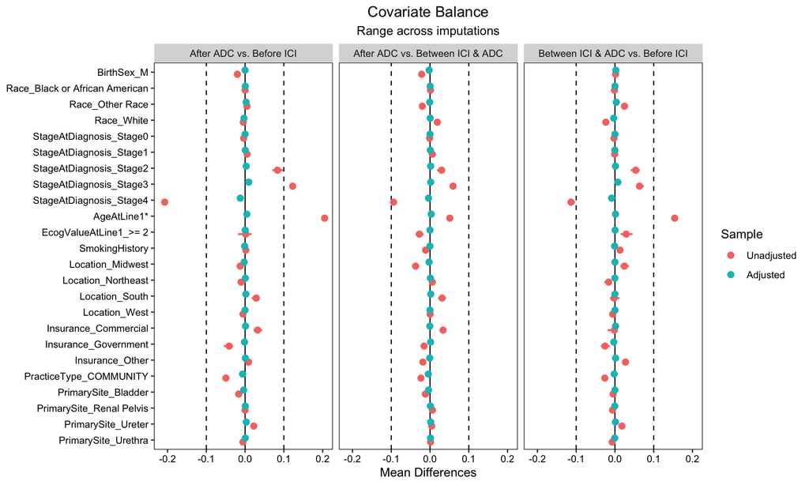

##### Survival curve

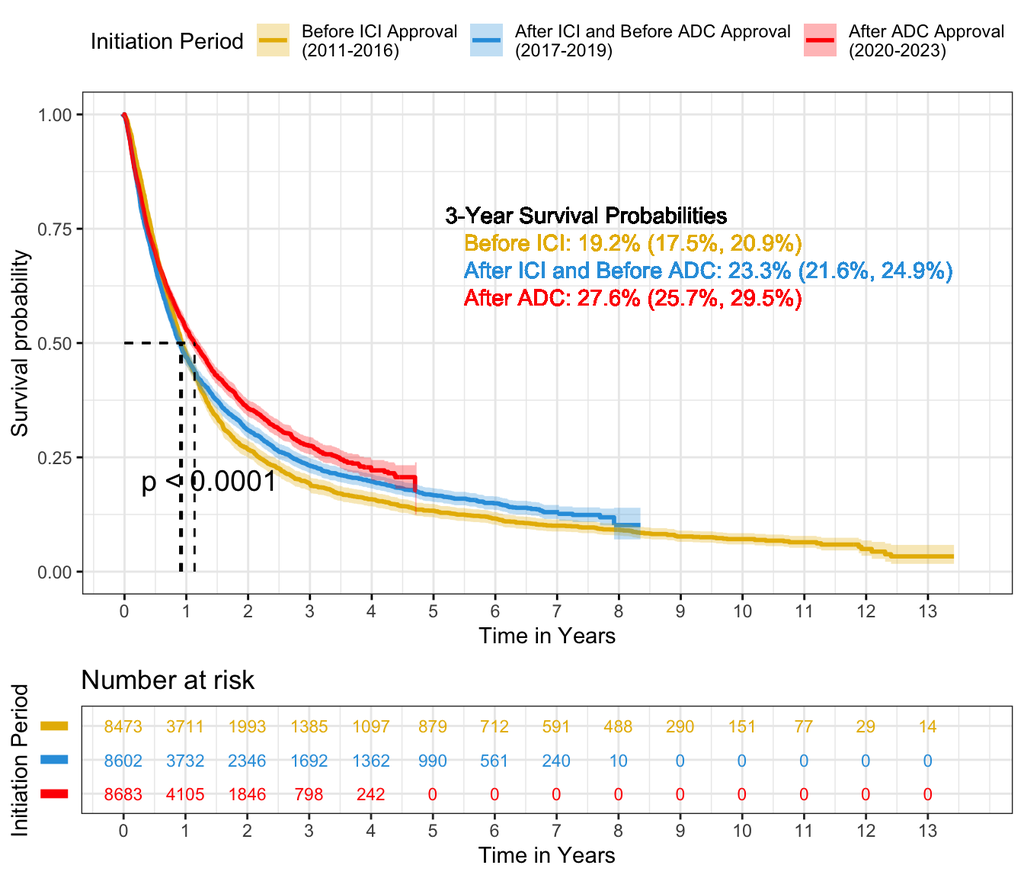

```
## Call: survfit(formula = Surv(time = as.numeric(CensoringDate - Line1StartDate),
##     event = Death) ~ Line1StartPeriod, data = auc, weights = wts1.mean,
##     conf.type = "log-log", se.fit = TRUE)
##
##                                    records    n events median 0.95LCL 0.95UCL
## Line1StartPeriod=Before ICI           2576 8495   7181    339     322     361
## Line1StartPeriod=Between ICI & ADC    2943 8636   6838    329     303     345
## Line1StartPeriod=After ADC            3436 8697   5500    414     385     448
```

##### Adjusted 3-yr survival probability

```
## Call: survfit(formula = Surv(time = as.numeric(CensoringDate - Line1StartDate),
##     event = Death) ~ Line1StartPeriod, data = auc, weights = wts1.mean,
##     conf.type = "log-log", se.fit = TRUE)
##
##                 Line1StartPeriod=Before ICI
##         time       n.risk      n.event     survival      std.err lower 95% CI
##     1.10e+03     1.39e+03     6.40e+03     1.92e-01     8.61e-03     1.76e-01
## upper 95% CI
##     2.10e-01
##
##                 Line1StartPeriod=Between ICI & ADC
##         time       n.risk      n.event     survival      std.err lower 95% CI
##     1.10e+03     1.69e+03     6.23e+03     2.32e-01     8.34e-03     2.16e-01
## upper 95% CI
##     2.48e-01
##
##                 Line1StartPeriod=After ADC
##         time       n.risk      n.event     survival      std.err lower 95% CI
##     1.10e+03     8.01e+02     5.38e+03     2.75e-01     9.62e-03     2.57e-01
## upper 95% CI
##     2.94e-01
```

```
## Chi-square statistic: 41.35271
```

```
## Degrees of freedom: 2
```

```
## P-value: 1.048031e-09
```

```
## [1] 1.431206
```

## 5.3 Covariate balance

```
##                         Stratified by Line1StartPeriod
##                          level                     Before ICI
##   n                                                8495.06
##   AgeAtLine1 (mean (SD))                             72.20 (9.20)
##   BirthSex (%)           F                          2255.9 (26.6)
##                          M                          6236.8 (73.4)
##   Race (%)               Black or African American   409.2 ( 5.1)
##                          Other Race                 1180.9 (14.9)
##                          White                      6356.1 (80.0)
##   StageAtDiagnosis (%)   Stage0                       31.1 ( 0.8)
##                          Stage1                      113.5 ( 2.8)
##                          Stage2                      551.7 (13.7)
##                          Stage3                      663.7 (16.5)
##                          Stage4                     2660.9 (66.2)
##   EcogValueAtLine1 (%)   < 2                        3252.4 (81.4)
##                          >= 2                        743.0 (18.6)
##   SmokingHistory (%)     FALSE                      2273.2 (26.8)
##                          TRUE                       6221.9 (73.2)
##   Location (%)           Midwest                     948.0 (14.9)
##                          Northeast                  1000.5 (15.8)
##                          South                      3323.4 (52.4)
##                          West                       1073.1 (16.9)
##   Insurance (%)          Commercial                 3629.8 (55.7)
##                          Government                 2266.6 (34.8)
##                          Other                       625.7 ( 9.6)
##   PracticeType (%)       ACADEMIC                   1642.1 (19.3)
##                          COMMUNITY                  6852.9 (80.7)
##   PrimarySite (%)        Bladder                    6613.9 (77.9)
##                          Renal Pelvis               1097.4 (12.9)
##                          Ureter                      721.5 ( 8.5)
##                          Urethra                      62.2 ( 0.7)
##                         Stratified by Line1StartPeriod
##                          Between ICI & ADC After ADC       SMD
##   n                      8635.50           8696.57
##   AgeAtLine1 (mean (SD))   72.22 (9.28)      72.25 (9.33)   0.003
##   BirthSex (%)            2273.6 (26.3)     2311.0 (26.6)   0.004
##                           6358.4 (73.7)     6385.5 (73.4)
##   Race (%)                 417.2 ( 5.4)      390.5 ( 5.4)   0.013
##                           1184.5 (15.2)     1061.5 (14.7)
##                           6191.7 (79.4)     5775.1 (79.9)
##   StageAtDiagnosis (%)      37.3 ( 0.8)       38.7 ( 0.8)   0.028
##                            137.3 ( 3.0)      148.5 ( 3.0)
##                            672.9 (14.6)      723.1 (14.7)
##                            787.8 (17.1)      841.3 (17.2)
##                           2979.7 (64.6)     3151.9 (64.3)
##   EcogValueAtLine1 (%)    4653.4 (80.1)     5132.3 (80.4)   0.022
##                           1156.9 (19.9)     1254.1 (19.6)
##   SmokingHistory (%)      2318.7 (26.9)     2336.9 (26.9)   0.002
##                           6316.8 (73.1)     6359.6 (73.1)
##   Location (%)             981.4 (14.8)      994.8 (14.6)   0.007
##                           1045.1 (15.8)     1085.1 (15.9)
##                           3476.4 (52.5)     3584.3 (52.6)
##                           1121.4 (16.9)     1151.2 (16.9)
##   Insurance (%)           4109.3 (56.0)     4312.1 (55.9)   0.013
##                           2503.8 (34.1)     2627.3 (34.1)
##                            728.7 ( 9.9)      773.7 (10.0)
##   PracticeType (%)        1686.4 (19.5)     1737.0 (20.0)   0.011
##                           6949.1 (80.5)     6959.6 (80.0)
##   PrimarySite (%)         6722.4 (77.8)     6736.6 (77.5)   0.012
##                           1111.1 (12.9)     1127.5 (13.0)
##                            744.2 ( 8.6)      764.6 ( 8.8)
##                             57.8 ( 0.7)       67.8 ( 0.8)
```